# S&P with Macroeconomic Index(final)

```python
%matplotlib inline
%matplotlib inline
import matplotlib.pyplot as plt
import seaborn as sns
import pandas as pd
import numpy as np
import warnings
import glob
import os
warnings.filterwarnings("ignore")
```

```python
ls
```

[output not shown]

[output cut: 72 more lines]

[output not shown]

```python
os.listdir("統計學習期末/")
```

```
['S&P500_1996-2020.csv',
 'stockprice.csv',
 'stock_select.csv',
 'stock_select_new.csv',
 '變數',
 '選股']
```

```python
glob.glob("統計學習期末/變數/__MACOSX/data/macroeconomic index/")
```

```
['統計學習期末/變數/__MACOSX/data/macroeconomic index/']
```

# Data Preprocessing & EDA

### S&P500 Index & VIX

```python
sp500=pd.read_csv("統計學習期末/變數/data/S&P500 index.csv", parse_dates=["Date"], index_col=0)
```

```python
vix=pd.read_csv("統計學習期末/變數/data/vix.csv", parse_dates=["Date"], index_col=0).sort_values(by=["Date"])
```

```python
sp500_mth_first=sp500.resample("M").agg({"Open":"first", "High":"first",
                                      "Low": "first", "Close":"first"})
sp500_mth_last=sp500.resample("M").agg({"Open":"last", "High":"last",
                                      "Low": "last", "Close":"last"})
```

```python
vix_mth_first=vix.resample("M").agg({"Open":"first", "High":"first",
                                      "Low": "first", "Close":"first"})
vix_mth_last=vix.resample("M").agg({"Open":"last", "High":"last",
                                      "Low": "last", "Close":"last"})
```

##### Monthly Return & Monthly Volatility

```python
sp500_mth_return=sp500_mth_last.pct_change(1)
vix_mth_volatility=vix_mth_last.pct_change(1)
```

##### Three Months Return & Three Months Volatility Rolling

```python
sp500_mth_return.reset_index(level=0, inplace=True)
monthly_date=sp500_mth_return["Date"].reset_index().drop(columns=["index"])
```

```python
sp500_3mths_return_rolling=sp500_mth_return.rolling(3).sum().merge(monthly_date, on=
                                             monthly_date.index).drop(columns=["key_0"]).set_index(["Date"]) * (252 ** 0.5) / (60 ** 0.5)
vix_3mths_volatility_rolling=vix_mth_volatility.rolling(3).sum().merge(monthly_date, on=
                                             monthly_date.index).drop(columns=["key_0"]).set_index(["Date"])
```

```python
sp500_vol=sp500.resample("M").sum()
sp500_3mths_vol_avg_rolling = sp500_vol.rolling(3).sum()
sp500_3mths_vol_avg_rolling = pd.DataFrame(sp500_3mths_vol_avg_rolling['Volume'].pct_change(3))
sp500_3mths_vol_avg_rolling.head(10)
```

| Date | Volume |
| --- | --- |
| 2000-01-31 | NaN |
| 2000-02-29 | NaN |
| 2000-03-31 | NaN |
| 2000-04-30 | NaN |
| 2000-05-31 | NaN |
| 2000-06-30 | -0.099464 |
| 2000-07-31 | -0.096003 |
| 2000-08-31 | -0.075118 |
| 2000-09-30 | -0.023516 |
| 2000-10-31 | 0.105848 |

```python
sp500_3mths_return_rolling.head()
```

| Date | Open | High | Low | Close |
| --- | --- | --- | --- | --- |
| 2000-01-31 | NaN | NaN | NaN | NaN |
| 2000-02-29 | NaN | NaN | NaN | NaN |
| 2000-03-31 | NaN | NaN | NaN | NaN |
| 2000-04-30 | 0.162714 | 0.125910 | 0.154065 | 0.093895 |
| 2000-05-31 | 0.121531 | 0.108012 | 0.111031 | 0.090192 |

```python
vix_3mths_volatility_rolling.head()
```

| Date | Open | High | Low | Close |
| --- | --- | --- | --- | --- |
| 2000-01-31 | NaN | NaN | NaN | NaN |
| 2000-02-29 | NaN | NaN | NaN | NaN |
| 2000-03-31 | NaN | NaN | NaN | NaN |
| 2000-04-30 | -0.035943 | -0.010488 | 0.033019 | 0.055024 |
| 2000-05-31 | 0.017109 | 0.017813 | 0.008250 | 0.021022 |

```python
sp500_3mths_vol_avg_rolling.head(8)
```

| Date | Volume |
| --- | --- |
| 2000-01-31 | NaN |
| 2000-02-29 | NaN |
| 2000-03-31 | NaN |
| 2000-04-30 | NaN |
| 2000-05-31 | NaN |
| 2000-06-30 | -0.099464 |
| 2000-07-31 | -0.096003 |
| 2000-08-31 | -0.075118 |

### Marcoeconomic Index

```python
glob.glob("data/macroeconomic index/*")
```

```
[]
```

```python
macro_lis=[
    "統計學習期末/變數/data/macroeconomic index/三個月美國政府公債殖利率.xlsx",
    "統計學習期末/變數/data/macroeconomic index/美國-10年期減2年期公債殖利率.xlsx",
    "統計學習期末/變數/data/macroeconomic index/US CPI MOM.xlsx",
    "統計學習期末/變數/data/macroeconomic index/US PMI.xlsx",
    "統計學習期末/變數/data/macroeconomic index/US PPI MOM.xlsx",
    "統計學習期末/變數/data/macroeconomic index/US  首次申請失業救濟金人數 季調.xlsx",
    "統計學習期末/變數/data/macroeconomic index/US 非農就業月增人數.xlsx"
]
```

```python
columns_lis=[""]
```

```python
marco_index_mth=pd.read_excel("統計學習期末/變數/data/macroeconomic index/US M2 貨幣供給量.xlsx")
for file in macro_lis:
    data=pd.read_excel(file)
    marco_index_mth=marco_index_mth.merge(data, on="Date")
```

```python
marco_index_mth.head()
```

|  | Date | M2 | TB_3MS | 10YR_PX_LAST | 2YR_PX_LAST | Interest_Spread | CPI | PMI | PPI | UI_Claims | NonFarm_Payrolls |
| --- | --- | --- | --- | --- | --- | --- | --- | --- | --- | --- | --- |
| 0 | 2020-11-30 | 19085.8 | 0.0712 | 0.8389 | 0.1485 | 0.6904 | 0.2 | 57.5 | 0.2 | 716 | 245 |
| 1 | 2020-10-31 | 18812.1 | 0.0864 | 0.8737 | 0.1525 | 0.7212 | 0.0 | 59.3 | 0.6 | 757 | 610 |
| 2 | 2020-09-30 | 18648.4 | 0.0915 | 0.6840 | 0.1270 | 0.5570 | 0.2 | 55.4 | 0.2 | 849 | 711 |
| 3 | 2020-08-31 | 18404.1 | 0.0938 | 0.7048 | 0.1309 | 0.5739 | 0.4 | 56.0 | 0.1 | 884 | 1493 |
| 4 | 2020-07-31 | 18322.3 | 0.0837 | 0.5282 | 0.1054 | 0.4228 | 0.6 | 54.2 | 0.6 | 1191 | 1761 |

```python
marco_index_mth.drop(columns=["10YR_PX_LAST", "2YR_PX_LAST"], inplace=True)
marco_index_mth=marco_index_mth.set_index(["Date"]).sort_values(by=["Date"])
marco_index_mth=marco_index_mth.loc["2000-01-31":"2020-11-30"]
```

```python
marco_index_mth.isna().sum()
```

```
M2                  0
TB_3MS              0
Interest_Spread     0
CPI                 0
PMI                 0
PPI                 0
UI_Claims           0
NonFarm_Payrolls    0
dtype: int64
```

##### Marco Index Monthly Data

```python
marco_index_mth.head()
```

| Date | M2 | TB_3MS | Interest_Spread | CPI | PMI | PPI | UI_Claims | NonFarm_Payrolls |
| --- | --- | --- | --- | --- | --- | --- | --- | --- |
| 2000-01-31 | 4647.2 | 5.692 | 0.074 | 0.3 | 56.7 | 0.0 | 285 | 234 |
| 2000-02-29 | 4660.6 | 5.781 | -0.112 | 0.4 | 55.8 | 1.0 | 280 | 116 |
| 2000-03-31 | 4691.5 | 5.871 | -0.475 | 0.6 | 54.9 | 0.5 | 266 | 473 |
| 2000-04-30 | 4747.3 | 5.829 | -0.464 | -0.1 | 54.7 | -0.3 | 291 | 291 |
| 2000-05-31 | 4734.6 | 5.619 | -0.400 | 0.2 | 53.2 | 0.1 | 280 | 218 |

##### Marco Index Three Months Return Data Rolling

```python
marco_index_mth['M2'] = marco_index_mth['M2'].pct_change(3)
marco_index_mth['TB_3MS'] = marco_index_mth['TB_3MS'].pct_change(3)
marco_index_mth['Interest_Spread'] = marco_index_mth['Interest_Spread'].pct_change(3)
marco_index_mth['PMI'] = marco_index_mth['PMI'].pct_change(3)
marco_index_mth['UI_Claims'] = marco_index_mth['UI_Claims'].pct_change(3)
```

```python
marco_index_3mths_ret = marco_index_mth
marco_index_3mths_ret.replace(np.inf, 0 , inplace = True)
marco_index_3mths_ret[np.isinf(marco_index_3mths_ret)] = 0
marco_index_3mths_ret
```

| Date | M2 | TB_3MS | Interest_Spread | CPI | PMI | PPI | UI_Claims | NonFarm_Payrolls |
| --- | --- | --- | --- | --- | --- | --- | --- | --- |
| 2000-01-31 | NaN | NaN | NaN | 0.3 | NaN | 0.0 | NaN | 234 |
| 2000-02-29 | NaN | NaN | NaN | 0.4 | NaN | 1.0 | NaN | 116 |
| 2000-03-31 | NaN | NaN | NaN | 0.6 | NaN | 0.5 | NaN | 473 |
| 2000-04-30 | 0.021540 | 0.024069 | -7.270270 | -0.1 | -0.035273 | -0.3 | 0.021053 | 291 |
| 2000-05-31 | 0.015878 | -0.028023 | 2.571429 | 0.2 | -0.046595 | 0.1 | 0.000000 | 218 |
| ... | ... | ... | ... | ... | ... | ... | ... | ... |
| 2020-07-31 | 0.076510 | 0.062183 | -0.047104 | 0.6 | 0.306024 | 0.6 | -0.692009 | 1761 |
| 2020-08-31 | 0.029969 | -0.247191 | 0.165753 | 0.4 | 0.299304 | 0.1 | -0.534001 | 1493 |
| 2020-09-30 | 0.026662 | -0.292343 | 0.097321 | 0.2 | 0.053232 | 0.2 | -0.397017 | 711 |
| 2020-10-31 | 0.026732 | 0.032258 | 0.705771 | 0.0 | 0.094096 | 0.6 | -0.364400 | 610 |
| 2020-11-30 | 0.037041 | -0.240938 | 0.202997 | 0.2 | 0.026786 | 0.2 | -0.190045 | 245 |

251 rows × 8 columns

##### Combine S&P Index with Marco Index

```python
y = sp500_3mths_return_rolling.shift(-3)['Close']
sp500_marco = pd.concat([y , marco_index_3mths_ret] , axis = 1)
sp500_marco['y'] = sp500_marco['Close']
sp500_marco['Close'] = sp500_marco['Close'].shift(3)
sp500_marco
```

| Date | Close | M2 | TB_3MS | Interest_Spread | CPI | PMI | PPI | UI_Claims | NonFarm_Payrolls | y |
| --- | --- | --- | --- | --- | --- | --- | --- | --- | --- | --- |
| 2000-01-31 | NaN | NaN | NaN | NaN | 0.3 | NaN | 0.0 | NaN | 234.0 | 0.093895 |
| 2000-02-29 | NaN | NaN | NaN | NaN | 0.4 | NaN | 1.0 | NaN | 116.0 | 0.090192 |
| 2000-03-31 | NaN | NaN | NaN | NaN | 0.6 | NaN | 0.5 | NaN | 473.0 | -0.058976 |
| 2000-04-30 | 0.093895 | 0.021540 | 0.024069 | -7.270270 | -0.1 | -0.035273 | -0.3 | 0.021053 | 291.0 | -0.029353 |
| 2000-05-31 | 0.090192 | 0.015878 | -0.028023 | 2.571429 | 0.2 | -0.046595 | 0.1 | 0.000000 | 218.0 | 0.139956 |
| ... | ... | ... | ... | ... | ... | ... | ... | ... | ... | ... |
| 2020-08-31 | 0.294199 | 0.029969 | -0.247191 | 0.165753 | 0.4 | 0.299304 | 0.1 | -0.534001 | 1493.0 | 0.083312 |
| 2020-09-30 | 0.176121 | 0.026662 | -0.292343 | 0.097321 | 0.2 | 0.053232 | 0.2 | -0.397017 | 711.0 | 0.209784 |
| 2020-10-31 | 0.006498 | 0.026732 | 0.032258 | 0.705771 | 0.0 | 0.094096 | 0.6 | -0.364400 | 610.0 | NaN |
| 2020-11-30 | 0.083312 | 0.037041 | -0.240938 | 0.202997 | 0.2 | 0.026786 | 0.2 | -0.190045 | 245.0 | NaN |
| 2020-12-31 | 0.209784 | NaN | NaN | NaN | NaN | NaN | NaN | NaN | NaN | NaN |

252 rows × 10 columns

##### Combine Volume

```python
sp500_marco = pd.concat([sp500_marco , sp500_3mths_vol_avg_rolling] , axis = 1)
sp500_marco.head(10)
```

| Date | Close | M2 | TB_3MS | Interest_Spread | CPI | PMI | PPI | UI_Claims | NonFarm_Payrolls | y | Volume |
| --- | --- | --- | --- | --- | --- | --- | --- | --- | --- | --- | --- |
| 2000-01-31 | NaN | NaN | NaN | NaN | 0.3 | NaN | 0.0 | NaN | 234.0 | 0.093895 | NaN |
| 2000-02-29 | NaN | NaN | NaN | NaN | 0.4 | NaN | 1.0 | NaN | 116.0 | 0.090192 | NaN |
| 2000-03-31 | NaN | NaN | NaN | NaN | 0.6 | NaN | 0.5 | NaN | 473.0 | -0.058976 | NaN |
| 2000-04-30 | 0.093895 | 0.021540 | 0.024069 | -7.270270 | -0.1 | -0.035273 | -0.3 | 0.021053 | 291.0 | -0.029353 | NaN |
| 2000-05-31 | 0.090192 | 0.015878 | -0.028023 | 2.571429 | 0.2 | -0.046595 | 0.1 | 0.000000 | 218.0 | 0.139956 | NaN |
| 2000-06-30 | -0.058976 | 0.012917 | -0.002725 | -0.303158 | 0.6 | -0.063752 | 0.8 | 0.056391 | -39.0 | -0.018701 | -0.099464 |
| 2000-07-31 | -0.029353 | 0.004782 | 0.066907 | -0.446121 | 0.3 | -0.040219 | 0.1 | 0.024055 | 168.0 | 0.004645 | -0.096003 |
| 2000-08-31 | 0.139956 | 0.013475 | 0.122442 | 0.095000 | 0.0 | -0.062030 | -0.2 | 0.114286 | -7.0 | -0.283843 | -0.075118 |
| 2000-09-30 | -0.018701 | 0.017277 | 0.060632 | -0.465257 | 0.5 | -0.033074 | 0.8 | 0.039146 | 124.0 | -0.165928 | -0.023516 |
| 2000-10-31 | 0.004645 | 0.016792 | 0.027336 | -0.365759 | 0.2 | -0.072381 | 0.4 | 0.010067 | 1.0 | -0.084801 | 0.105848 |

##### Combine VIX

```python
vix_3mths_volatility_rolling = pd.DataFrame(vix_3mths_volatility_rolling['Close'])
vix_3mths_volatility_rolling.rename(columns = {"Close":"VIX"} , inplace = True)
vix_3mths_volatility_rolling
```

| Date | VIX |
| --- | --- |
| 2000-01-31 | NaN |
| 2000-02-29 | NaN |
| 2000-03-31 | NaN |
| 2000-04-30 | 0.055024 |
| 2000-05-31 | 0.021022 |
| ... | ... |
| 2020-08-31 | -0.010323 |
| 2020-09-30 | -0.117981 |
| 2020-10-31 | 0.519997 |
| 2020-11-30 | -0.018694 |
| 2020-12-31 | 0.029491 |

252 rows × 1 columns

```python
sp500_marco_vix = pd.concat([sp500_marco , vix_3mths_volatility_rolling] , axis = 1)
sp500_marco_vix
```

| Date | Close | M2 | TB_3MS | Interest_Spread | CPI | PMI | PPI | UI_Claims | NonFarm_Payrolls | y | Volume | VIX |
| --- | --- | --- | --- | --- | --- | --- | --- | --- | --- | --- | --- | --- |
| 2000-01-31 | NaN | NaN | NaN | NaN | 0.3 | NaN | 0.0 | NaN | 234.0 | 0.093895 | NaN | NaN |
| 2000-02-29 | NaN | NaN | NaN | NaN | 0.4 | NaN | 1.0 | NaN | 116.0 | 0.090192 | NaN | NaN |
| 2000-03-31 | NaN | NaN | NaN | NaN | 0.6 | NaN | 0.5 | NaN | 473.0 | -0.058976 | NaN | NaN |
| 2000-04-30 | 0.093895 | 0.021540 | 0.024069 | -7.270270 | -0.1 | -0.035273 | -0.3 | 0.021053 | 291.0 | -0.029353 | NaN | 0.055024 |
| 2000-05-31 | 0.090192 | 0.015878 | -0.028023 | 2.571429 | 0.2 | -0.046595 | 0.1 | 0.000000 | 218.0 | 0.139956 | NaN | 0.021022 |
| ... | ... | ... | ... | ... | ... | ... | ... | ... | ... | ... | ... | ... |
| 2020-08-31 | 0.294199 | 0.029969 | -0.247191 | 0.165753 | 0.4 | 0.299304 | 0.1 | -0.534001 | 1493.0 | 0.083312 | -0.201959 | -0.010323 |
| 2020-09-30 | 0.176121 | 0.026662 | -0.292343 | 0.097321 | 0.2 | 0.053232 | 0.2 | -0.397017 | 711.0 | 0.209784 | -0.241888 | -0.117981 |
| 2020-10-31 | 0.006498 | 0.026732 | 0.032258 | 0.705771 | 0.0 | 0.094096 | 0.6 | -0.364400 | 610.0 | NaN | -0.205397 | 0.519997 |
| 2020-11-30 | 0.083312 | 0.037041 | -0.240938 | 0.202997 | 0.2 | 0.026786 | 0.2 | -0.190045 | 245.0 | NaN | -0.095456 | -0.018694 |
| 2020-12-31 | 0.209784 | NaN | NaN | NaN | NaN | NaN | NaN | NaN | NaN | NaN | -0.000525 | 0.029491 |

252 rows × 12 columns

```python
sp500_marco_vix2 = sp500_marco_vix
```

### Data Period: 2000/01/01-2020/11/30

### S&P500 Index

```python
len(set(sp500_3mths_return_rolling["Close"]))
```

```
252
```

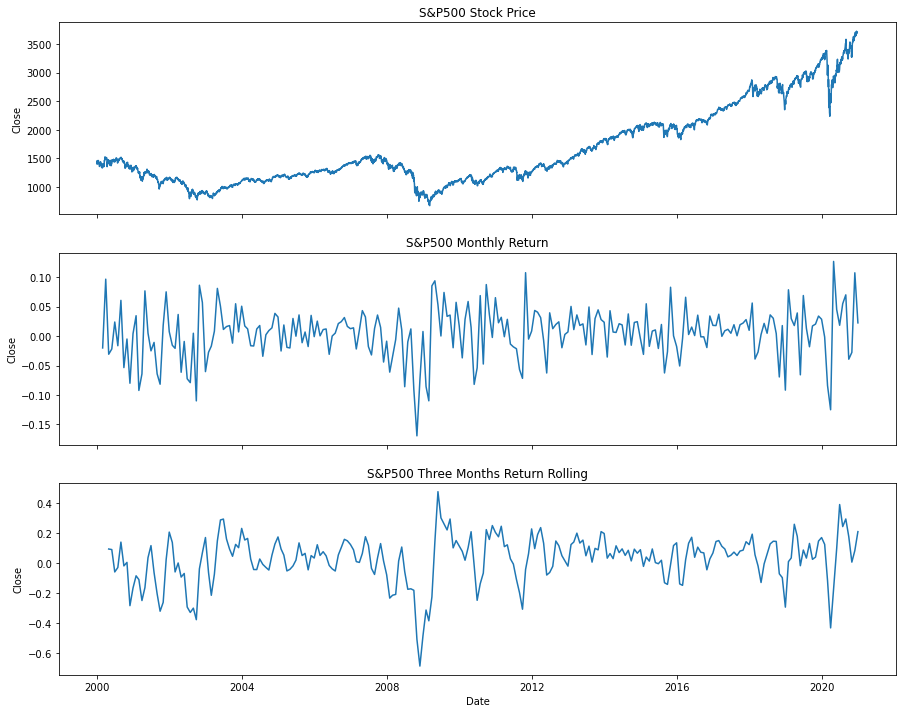

```python
fig, axes=plt.subplots(3, 1, figsize=(15, 12), sharex=True)
sns.lineplot(x=sp500.index, y=sp500.Close, linewidth=1.5, ax=axes[0])
sns.lineplot(x=sp500_mth_return.Date, y=sp500_mth_return.Close, linewidth=1.5, ax=axes[1])
sns.lineplot(x=sp500_3mths_return_rolling.index, y=sp500_3mths_return_rolling.Close, linewidth=1.5, ax=axes[2])

axes[0].set_title("S&P500 Stock Price")
axes[1].set_title("S&P500 Monthly Return")
axes[2].set_title("S&P500 Three Months Return Rolling");
```

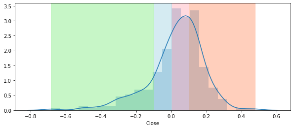

```python
plt.subplots(figsize=(10, 4))
sns.distplot(sp500_3mths_return_rolling["Close"])
plt.axvspan(xmin=0, xmax=0.1, color="lightpink", alpha=0.5)
plt.axvspan(xmin=0, xmax=-0.1, color="lightblue", alpha=0.5)
plt.axvspan(xmin=-0.1, xmax=sp500_3mths_return_rolling["Close"].min(), color="lightgreen", alpha=0.5)
plt.axvspan(xmin=0.1, xmax=sp500_3mths_return_rolling["Close"].max(), color="lightsalmon", alpha=0.5)
```

```python
print("Maximum Return:"+str(round(sp500_marco_vix["Close"].max(), 2)))
print("Minimum Return:"+str(round(sp500_marco_vix["Close"].min(), 2)))
```

```
Maximum Return:0.48
Minimum Return:-0.69
```

### Marco Index

- Series Plot

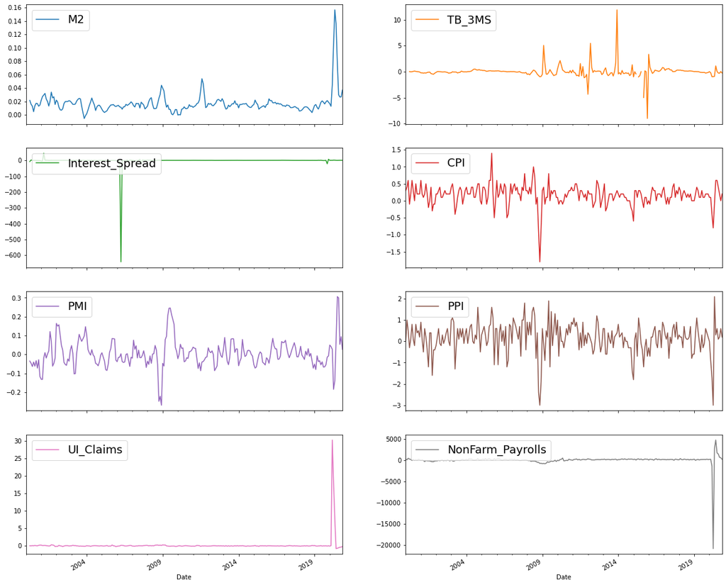

```python
marco_index_3mths_ret.plot(subplots=True, layout=(4,2), linewidth=1.5, figsize=(20, 18));
[ax.legend(loc="upper left", prop={"size": 18}) for ax in plt.gcf().axes]; #get current figure
```

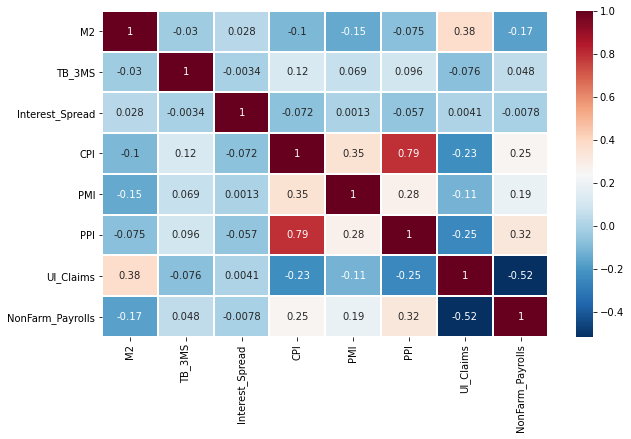

```python
plt.subplots(figsize=(10, 6))
sns.heatmap(marco_index_3mths_ret.corr(), linewidths=1, cmap="RdBu_r", annot=True)
```

### S&P500 / Macro Index / VIX / Volume 關係

- Correlation

```python
sp500_marco_vix
```

| Date | Close | M2 | TB_3MS | Interest_Spread | CPI | PMI | PPI | UI_Claims | NonFarm_Payrolls | y | Volume | VIX |
| --- | --- | --- | --- | --- | --- | --- | --- | --- | --- | --- | --- | --- |
| 2000-01-31 | NaN | NaN | NaN | NaN | 0.3 | NaN | 0.0 | NaN | 234.0 | 0.093895 | NaN | NaN |
| 2000-02-29 | NaN | NaN | NaN | NaN | 0.4 | NaN | 1.0 | NaN | 116.0 | 0.090192 | NaN | NaN |
| 2000-03-31 | NaN | NaN | NaN | NaN | 0.6 | NaN | 0.5 | NaN | 473.0 | -0.058976 | NaN | NaN |
| 2000-04-30 | 0.093895 | 0.021540 | 0.024069 | -7.270270 | -0.1 | -0.035273 | -0.3 | 0.021053 | 291.0 | -0.029353 | NaN | 0.055024 |
| 2000-05-31 | 0.090192 | 0.015878 | -0.028023 | 2.571429 | 0.2 | -0.046595 | 0.1 | 0.000000 | 218.0 | 0.139956 | NaN | 0.021022 |
| ... | ... | ... | ... | ... | ... | ... | ... | ... | ... | ... | ... | ... |
| 2020-08-31 | 0.294199 | 0.029969 | -0.247191 | 0.165753 | 0.4 | 0.299304 | 0.1 | -0.534001 | 1493.0 | 0.083312 | -0.201959 | -0.010323 |
| 2020-09-30 | 0.176121 | 0.026662 | -0.292343 | 0.097321 | 0.2 | 0.053232 | 0.2 | -0.397017 | 711.0 | 0.209784 | -0.241888 | -0.117981 |
| 2020-10-31 | 0.006498 | 0.026732 | 0.032258 | 0.705771 | 0.0 | 0.094096 | 0.6 | -0.364400 | 610.0 | NaN | -0.205397 | 0.519997 |
| 2020-11-30 | 0.083312 | 0.037041 | -0.240938 | 0.202997 | 0.2 | 0.026786 | 0.2 | -0.190045 | 245.0 | NaN | -0.095456 | -0.018694 |
| 2020-12-31 | 0.209784 | NaN | NaN | NaN | NaN | NaN | NaN | NaN | NaN | NaN | -0.000525 | 0.029491 |

252 rows × 12 columns

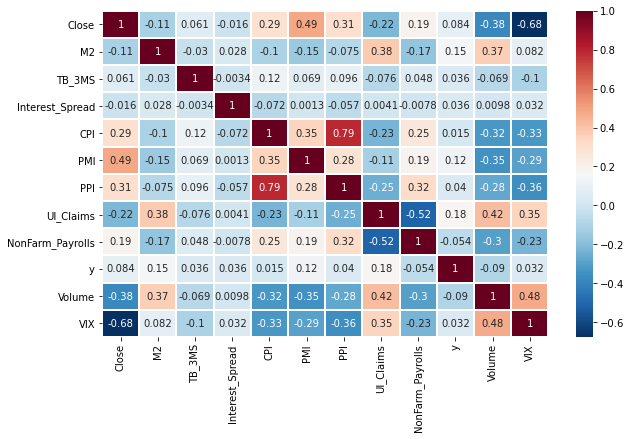

```python
plt.subplots(figsize=(10, 6))
sns.heatmap(sp500_marco_vix.corr(), linewidths=1, cmap="RdBu_r", annot=True)
```

```python
sp500_marco_vix = sp500_marco_vix.drop(columns=["TB_3MS", "VIX", "Interest_Spread"])
```

```python
sp500_marco_vix.dropna(axis = 0 , inplace = True)
```

```python
sp500_marco_vix
```

| Date | Close | M2 | CPI | PMI | PPI | UI_Claims | NonFarm_Payrolls | y | Volume |
| --- | --- | --- | --- | --- | --- | --- | --- | --- | --- |
| 2000-06-30 | -0.058976 | 0.012917 | 0.6 | -0.063752 | 0.8 | 0.056391 | -39.0 | -0.018701 | -0.099464 |
| 2000-07-31 | -0.029353 | 0.004782 | 0.3 | -0.040219 | 0.1 | 0.024055 | 168.0 | 0.004645 | -0.096003 |
| 2000-08-31 | 0.139956 | 0.013475 | 0.0 | -0.062030 | -0.2 | 0.114286 | -7.0 | -0.283843 | -0.075118 |
| 2000-09-30 | -0.018701 | 0.017277 | 0.5 | -0.033074 | 0.8 | 0.039146 | 124.0 | -0.165928 | -0.023516 |
| 2000-10-31 | 0.004645 | 0.016792 | 0.2 | -0.072381 | 0.4 | 0.010067 | 1.0 | -0.084801 | 0.105848 |
| ... | ... | ... | ... | ... | ... | ... | ... | ... | ... |
| 2020-05-31 | 0.096335 | 0.156776 | -0.1 | -0.139721 | 2.1 | 7.741935 | 2725.0 | 0.294199 | 0.678143 |
| 2020-06-30 | 0.390438 | 0.135973 | 0.6 | 0.071283 | 0.3 | -0.794961 | 4781.0 | 0.176121 | 0.116983 |
| 2020-07-31 | 0.243409 | 0.076510 | 0.6 | 0.306024 | 0.6 | -0.692009 | 1761.0 | 0.006498 | -0.092664 |
| 2020-08-31 | 0.294199 | 0.029969 | 0.4 | 0.299304 | 0.1 | -0.534001 | 1493.0 | 0.083312 | -0.201959 |
| 2020-09-30 | 0.176121 | 0.026662 | 0.2 | 0.053232 | 0.2 | -0.397017 | 711.0 | 0.209784 | -0.241888 |

244 rows × 9 columns

```python
sp500_marco_vix.isna().sum()
```

```
Close               0
M2                  0
CPI                 0
PMI                 0
PPI                 0
UI_Claims           0
NonFarm_Payrolls    0
y                   0
Volume              0
dtype: int64
```

### S&P500 與 Macro Index PCA

```python
from sklearn.model_selection import train_test_split
from sklearn.preprocessing import StandardScaler

X_sp500=sp500_marco_vix.drop(["y"], axis=1)
y_sp500=sp500_marco_vix[["y"]]

# X_sp500_train, X_sp500_test, y_sp500_train, y_sp500_test=train_test_split(X_sp500, y_sp500
#                                                                           ,test_size=0.15, random_state=24)

# 2010-2018 樣本內
# 2019-2020 樣本外
X_sp500_train=X_sp500[:222]
X_sp500_test=X_sp500[222:]
y_sp500_train=y_sp500[:222]
y_sp500_test=y_sp500[222:]

scaler=StandardScaler()
X_sp500_train_scale=scaler.fit_transform(X_sp500_train)
X_sp500_test_scale=scaler.transform(X_sp500_test)
```

```python
print("X_sp500_train",X_sp500_train.shape)
print("X_sp500_test",X_sp500_test.shape)
print("y_sp500_train",y_sp500_train.shape)
print("y_sp500_test",y_sp500_test.shape)
```

```
X_sp500_train (222, 8)
X_sp500_test (22, 8)
y_sp500_train (222, 1)
y_sp500_test (22, 1)
```

```python
from sklearn.decomposition import PCA

pca=PCA()
pca.fit(X_sp500_train_scale)
```

```
PCA()
```

```python
print("total components: "+ "\n" + str(pca.n_components_))
print("explained ratio: " + "\n" + str(pca.explained_variance_ratio_))
```

```
total components:
8
explained ratio:
[0.37644624 0.18799365 0.12799099 0.10008102 0.08658532 0.05568224
 0.04361497 0.02160556]
```

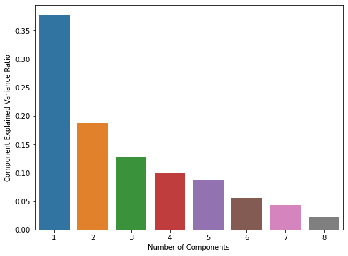

```python
plt.subplots(figsize=(8, 6))
sns.barplot(x=[i for i in range(1, len(X_sp500_train.columns.to_list())+1)], y=pca.explained_variance_ratio_)
plt.xlabel("Number of Components");
plt.ylabel("Component Explained Variance Ratio");
```

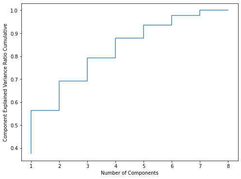

```python
plt.subplots(figsize=(8, 6))
cumulative=np.cumsum(pca.explained_variance_ratio_)
plt.step([i for i in range(1, len(cumulative)+1)], cumulative, color="steelblue")
plt.xlabel("Number of Components");
plt.ylabel("Component Explained Variance Ratio Cumulative");
```

```python
#apply pca components 4
pca=PCA(n_components=5)
X_sp500_train_scale_trans=pca.fit_transform(X_sp500_train_scale)
```

```python
X_sp500_train_scale_trans.shape
```

```
(222, 5)
```

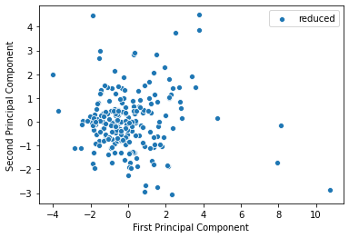

```python
sns.scatterplot(x=X_sp500_train_scale_trans[:,0], y=X_sp500_train_scale_trans[:,1], label="reduced")
plt.xlabel("First Principal Component")
plt.ylabel("Second Principal Component");
```

### Model - Regression

```python
from sklearn.metrics import mean_squared_error, mean_absolute_error
from sklearn.linear_model import LinearRegression, Lasso, Ridge
from sklearn.ensemble import GradientBoostingRegressor, RandomForestRegressor
from sklearn.tree import DecisionTreeRegressor
from sklearn.linear_model import SGDRegressor
from sklearn.svm import LinearSVR
from xgboost import XGBRegressor
from sklearn import tree


mae_compare=pd.DataFrame(columns=["Algorithm", "MAE", "Score"])
```

##### LinearRegression

```python
lr=LinearRegression()
lr.fit(X_sp500_train_scale, y_sp500_train)
lr_pred=lr.predict(X_sp500_train_scale)

#mae_compare["LinearRegression"]=mean_absolute_error(y_sp500_train, lr_pred)
mae_compare=mae_compare.append({"Algorithm":"LinearRegression",
             "MAE":mean_squared_error(y_sp500_train, lr_pred),
                                "Score":lr.score(X_sp500_train_scale, y_sp500_train)}, ignore_index=True)
```

[output not shown]

##### Stochastic Gradient Descent Regressor

```python
sgdr=SGDRegressor()
sgdr.fit(X_sp500_train_scale, y_sp500_train)
sgdr_pred=sgdr.predict(X_sp500_train_scale)

# mae_compare["SGDRegressor"]=mean_absolute_error(y_sp500_train, sgdr_pred)
mae_compare=mae_compare.append({"Algorithm":"SGDRegressor",
             "MAE":mean_squared_error(y_sp500_train, sgdr_pred),
                                "Score":sgdr.score(X_sp500_train_scale, y_sp500_train)}, ignore_index=True)
```

##### Lasso

```python
lasso = Lasso()#alpha=0.0005)
lasso.fit(X_sp500_train_scale, y_sp500_train)
lasso_pred = lasso.predict(X_sp500_train_scale)

# mae_compare["Lasso"]=mean_absolute_error(y_sp500_train, lasso_pred)
mae_compare=mae_compare.append({"Algorithm":"Lasso",
             "MAE":mean_squared_error(y_sp500_train, lasso_pred),
                                "Score":lasso.score(X_sp500_train_scale, y_sp500_train)}, ignore_index=True)
```

##### Ridge

```python
ridge = Ridge()#alpha=0.002)
ridge.fit(X_sp500_train_scale, y_sp500_train)
ridge_pred = ridge.predict(X_sp500_train_scale)

# mae_compare["Ridge"]=mean_absolute_error(y_sp500_train, ridge_pred)
mae_compare=mae_compare.append({"Algorithm":"Ridge",
             "MAE":mean_squared_error(y_sp500_train, ridge_pred),
                                "Score":ridge.score(X_sp500_train_scale, y_sp500_train)}, ignore_index=True)
```

##### Linear SVM

```python
svm_reg=LinearSVR()
svm_reg.fit(X_sp500_train_scale, y_sp500_train)
svm_reg_pred=svm_reg.predict(X_sp500_train_scale)

# mae_compare["LinearSVM"]=mean_absolute_error(y_sp500_train, svm_reg_pred)
mae_compare=mae_compare.append({"Algorithm":"LinearSVM",
             "MAE":mean_squared_error(y_sp500_train, svm_reg_pred),
                                "Score":svm_reg.score(X_sp500_train_scale, y_sp500_train)}, ignore_index=True)
```

##### Decision Tree Regressor

```python
tree_reg=DecisionTreeRegressor()
tree_reg.fit(X_sp500_train, y_sp500_train)
tree_reg_pred=tree_reg.predict(X_sp500_train)

# mae_compare["DecisionTreeRegressor"]=mean_absolute_error(y_sp500_train, tree_reg_pred)
mae_compare=mae_compare.append({"Algorithm":"DecisionTreeRegressor",
             "MAE":mean_squared_error(y_sp500_train, tree_reg_pred),
                                "Score":tree_reg.score(X_sp500_train, y_sp500_train)}, ignore_index=True)
```

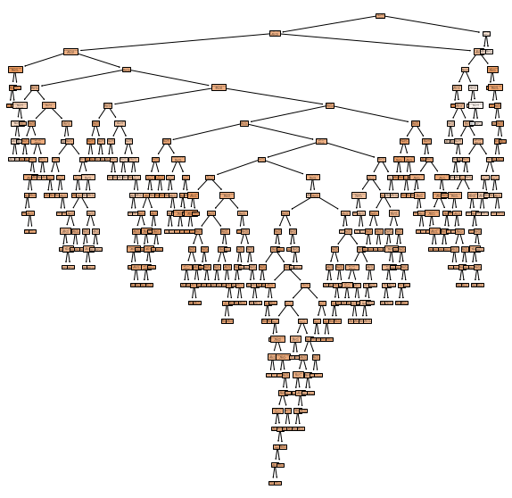

```python
from sklearn import tree
fig = plt.figure(figsize=(10,10))
_ = tree.plot_tree(tree_reg, feature_names=X_sp500.columns, filled=True)
```

```python
pd.DataFrame({"features":X_sp500.columns, "features_importances":
              tree_reg.feature_importances_}).sort_values(by="features_importances", ascending=False)
```

|  | features | features_importances |
| --- | --- | --- |
| 5 | UI_Claims | 0.218518 |
| 7 | Volume | 0.201670 |
| 0 | Close | 0.160328 |
| 6 | NonFarm_Payrolls | 0.145091 |
| 3 | PMI | 0.141592 |
| 1 | M2 | 0.089965 |
| 4 | PPI | 0.030667 |
| 2 | CPI | 0.012168 |

##### Random Forest Regressor

```python
rf = RandomForestRegressor()
rf.fit(X_sp500_train, y_sp500_train)
rf_pred = rf.predict(X_sp500_train)

# mae_compare["RandomForest"]=mean_absolute_error(y_sp500_train, rf_pred)
mae_compare=mae_compare.append({"Algorithm":"RandomForest",
             "MAE":mean_squared_error(y_sp500_train, rf_pred),
                                "Score":rf.score(X_sp500_train, y_sp500_train)}, ignore_index=True)
```

##### Gradient Boosting Regressor

```python
gbr=GradientBoostingRegressor()#max_depth=3, n_estimators=3, learning_rate=0.7)
gbr.fit(X_sp500_train, y_sp500_train)
gbr_pred=gbr.predict(X_sp500_train)

# mae_compare["GradientBoostingRegressor"]=mean_absolute_error(y_sp500_train, gbr_pred)
mae_compare=mae_compare.append({"Algorithm":"GradientBoostingRegressor",
             "MAE":mean_squared_error(y_sp500_train, gbr_pred),
                                "Score":gbr.score(X_sp500_train, y_sp500_train)}, ignore_index=True)
```

```python
pd.DataFrame({"features":X_sp500.columns, "features_importances":
              gbr.feature_importances_}).sort_values(by="features_importances", ascending=False)
```

|  | features | features_importances |
| --- | --- | --- |
| 5 | UI_Claims | 0.248148 |
| 7 | Volume | 0.209965 |
| 3 | PMI | 0.143646 |
| 0 | Close | 0.134503 |
| 6 | NonFarm_Payrolls | 0.131404 |
| 1 | M2 | 0.089251 |
| 2 | CPI | 0.024132 |
| 4 | PPI | 0.018951 |

##### XGBoost Regressor

```python
xgbr=XGBRegressor()
xgbr.fit(X_sp500_train, y_sp500_train)
xgbr_pred=xgbr.predict(X_sp500_train)

# mae_compare["XGBoostRegressor"]= mean_absolute_error(y_sp500_train, xgbr_pred)
mae_compare=mae_compare.append({"Algorithm":"XGBoostRegressor",
             "MAE":mean_squared_error(y_sp500_train, xgbr_pred),
                                "Score":xgbr.score(X_sp500_train, y_sp500_train)}, ignore_index=True)
```

```python
mae_compare.set_index(["Algorithm"])
```

| Algorithm | MAE | Score |
| --- | --- | --- |
| LinearRegression | 2.131640e-02 | 0.116521 |
| SGDRegressor | 2.139183e-02 | 0.113394 |
| Lasso | 2.412778e-02 | 0.000000 |
| Ridge | 2.131653e-02 | 0.116515 |
| LinearSVM | 2.397672e-02 | 0.006261 |
| DecisionTreeRegressor | 0.000000e+00 | 1.000000 |
| RandomForest | 2.825153e-03 | 0.882909 |
| GradientBoostingRegressor | 2.445366e-03 | 0.898649 |
| XGBoostRegressor | 9.323675e-07 | 0.999961 |

### Cross Validation

```python
from sklearn.model_selection import cross_val_score

n_folds = 10
# =========================================================================
scores = cross_val_score(lr, X_sp500_train_scale, y_sp500_train, scoring="neg_mean_squared_error",
                         cv=n_folds)
# mae_scores = np.sqrt(-scores)
mae_scores = (-scores)
print("LinearRegression:")
print("Mean RMSE = " + str(mae_scores.mean().round(5)))
print("Error std deviation = " +str(mae_scores.std().round(5)))
```

```
LinearRegression:
Mean RMSE = 0.02651
Error std deviation = 0.0261
```

```python
n_folds = 10
# =========================================================================
scores = cross_val_score(gbr, X_sp500_train, y_sp500_train, scoring="neg_mean_squared_error",
                         cv=n_folds)
# mae_scores = np.sqrt(-scores)
mae_scores = (-scores)
print("GradientBoostingRegressor:")
print("Mean RMSE = " + str(mae_scores.mean().round(5)))
print("Error std deviation = " +str(mae_scores.std().round(5)))
```

```
GradientBoostingRegressor:
Mean RMSE = 0.02823
Error std deviation = 0.02421
```

```python
scores = cross_val_score(rf, X_sp500_train, y_sp500_train, scoring="neg_mean_squared_error",
                         cv=n_folds)
# mae_scores = np.sqrt(-scores)
mae_scores = (-scores)
print("RandomForest:")
print("Mean RMSE = " + str(mae_scores.mean().round(5)))
print("Error std deviation = " +str(mae_scores.std().round(5)))
```

```
RandomForest:
Mean RMSE = 0.0254
Error std deviation = 0.02283
```

```python
scores = cross_val_score(xgbr, X_sp500_train, y_sp500_train, scoring="neg_mean_squared_error",
                         cv=n_folds)
# mae_scores = np.sqrt(-scores)
mae_scores = (-scores)
print("XGBoostRegressor:")
print("Mean RMSE = " + str(mae_scores.mean().round(5)))
print("Error std deviation = " +str(mae_scores.std().round(5)))
```

```
XGBoostRegressor:
Mean RMSE = 0.03039
Error std deviation = 0.02693
```

### Select Best Algorithms & Fine Tuning

```python
from sklearn.model_selection import GridSearchCV

# Tuning XGBoost
param_grid = [{"n_estimators": [700, 800, 900],
               "learning_rate": [0.005, 0.01, 0.05],
              "max_depth": [1, 2, 3]}]

xgbr_tuning = XGBRegressor()
grid_search = GridSearchCV(xgbr_tuning, param_grid, cv=5,
                           scoring="neg_mean_squared_error")

grid_search.fit(X_sp500_train, y_sp500_train)

grid_search.best_params_
```

```
{'learning_rate': 0.005, 'max_depth': 1, 'n_estimators': 800}
```

```python
param_grid = [{"n_estimators": [600, 700, 800],
              "max_depth": [2, 3, 4]}]

rfg_tuning = RandomForestRegressor()
grid_search = GridSearchCV(rfg_tuning, param_grid, cv=5,
                           scoring="neg_mean_squared_error")

grid_search.fit(X_sp500_train, y_sp500_train)

grid_search.best_params_
```

```
{'max_depth': 2, 'n_estimators': 700}
```

```python
param_grid = [{"n_estimators": [600, 700, 800],
               "learning_rate": [0.005, 0.01, 0.05],
              "max_depth": [1, 2, 3]}]

gbr_tuning = GradientBoostingRegressor()
grid_search = GridSearchCV(gbr_tuning, param_grid, cv=5,
                           scoring="neg_mean_squared_error")

grid_search.fit(X_sp500_train, y_sp500_train)

grid_search.best_params_
```

```
{'learning_rate': 0.005, 'max_depth': 1, 'n_estimators': 600}
```

```python
param_grid = [{"max_features": [4, 6, 7],
              "max_depth": [1, 2, 3]}]

dtr_tuning = DecisionTreeRegressor()
grid_search = GridSearchCV(dtr_tuning, param_grid, cv=5,
                           scoring="neg_mean_squared_error")

grid_search.fit(X_sp500_train, y_sp500_train)

grid_search.best_params_
```

```
{'max_depth': 1, 'max_features': 4}
```

### Create Final Model

```python
final_model_dtr = DecisionTreeRegressor(max_features=4, max_depth=1)

final_model_dtr.fit(X_sp500_train, y_sp500_train)
dtr_final_model_train = final_model_dtr.predict(X_sp500_train)
dtr_final_model_test = final_model_dtr.predict(X_sp500_test)
```

```python
final_model_rfg = RandomForestRegressor(n_estimators=700, max_depth=2)

final_model_rfg.fit(X_sp500_train, y_sp500_train)
rfg_final_model_train = final_model_rfg.predict(X_sp500_train)
rfg_final_model_test = final_model_rfg.predict(X_sp500_test)
```

```python
final_model_xgbr = XGBRegressor(n_estimators=800, learning_rate=0.005, max_depth=1)

final_model_xgbr.fit(X_sp500_train, y_sp500_train)
xgbr_final_model_train = final_model_xgbr.predict(X_sp500_train)
xgbr_final_model_test = final_model_xgbr.predict(X_sp500_test)
```

```python
final_model_gbr = GradientBoostingRegressor(n_estimators=600, learning_rate=0.005, max_depth=1)

final_model_gbr.fit(X_sp500_train, y_sp500_train)
gbr_final_model_train = final_model_gbr.predict(X_sp500_train)
gbr_final_model_test = final_model_gbr.predict(X_sp500_test)
```

```python
predict_train = pd.concat([pd.DataFrame(rfg_final_model_train) , pd.DataFrame(xgbr_final_model_train) , pd.DataFrame(gbr_final_model_train)] , axis = 1)
predict_train.columns = ['rfg' , 'xgbr' , 'gbr']
predict_train.index = y_sp500_train.index
predict_train
```

| Date | rfg | xgbr | gbr |
| --- | --- | --- | --- |
| 2000-06-30 | 0.029716 | 0.039373 | 0.029346 |
| 2000-07-31 | 0.024654 | 0.024099 | 0.016620 |
| 2000-08-31 | -0.010421 | -0.042144 | -0.049328 |
| 2000-09-30 | 0.027844 | 0.033953 | 0.027641 |
| 2000-10-31 | 0.028963 | 0.034835 | 0.027641 |
| ... | ... | ... | ... |
| 2018-07-31 | 0.029538 | 0.037297 | 0.027641 |
| 2018-08-31 | 0.029183 | 0.021288 | 0.015420 |
| 2018-09-30 | 0.029555 | 0.021636 | 0.016620 |
| 2018-10-31 | 0.018576 | 0.019561 | 0.014914 |
| 2018-11-30 | -0.019743 | -0.025184 | -0.025407 |

222 rows × 3 columns

```python
predict_test = pd.concat([pd.DataFrame(rfg_final_model_test) , pd.DataFrame(xgbr_final_model_test) , pd.DataFrame(gbr_final_model_test)] , axis = 1)
predict_test.columns = ['rfg' , 'xgbr' , 'gbr']
predict_test.index = y_sp500_test.index
predict_test
```

| Date | rfg | xgbr | gbr |
| --- | --- | --- | --- |
| 2018-12-31 | -0.022835 | 0.003658 | 0.014914 |
| 2019-01-31 | 0.008103 | 0.006223 | -0.002150 |
| 2019-02-28 | 0.030040 | 0.034835 | 0.027641 |
| 2019-03-31 | 0.041126 | 0.043600 | 0.029346 |
| 2019-04-30 | 0.027582 | 0.024981 | 0.016620 |
| 2019-05-31 | 0.033754 | 0.036562 | 0.028146 |
| 2019-06-30 | 0.028523 | 0.039024 | 0.028146 |
| 2019-07-31 | 0.032332 | 0.038180 | 0.027641 |
| 2019-08-31 | 0.031770 | 0.038180 | 0.027641 |
| 2019-09-30 | 0.031593 | 0.038180 | 0.027641 |
| 2019-10-31 | 0.032025 | 0.038180 | 0.027641 |
| 2019-11-30 | 0.031675 | 0.038180 | 0.027641 |
| 2019-12-31 | 0.032134 | 0.038180 | 0.027641 |
| 2020-01-31 | 0.035316 | 0.039907 | 0.028146 |
| 2020-02-29 | 0.025962 | 0.037297 | 0.027641 |
| 2020-03-31 | -0.167234 | 0.007429 | -0.036588 |
| 2020-04-30 | -0.225667 | -0.008001 | -0.059193 |
| 2020-05-31 | -0.236702 | -0.049365 | -0.103835 |
| 2020-06-30 | 0.009758 | 0.059843 | 0.042478 |
| 2020-07-31 | 0.014781 | 0.065263 | 0.044184 |
| 2020-08-31 | 0.043691 | 0.121562 | 0.091271 |
| 2020-09-30 | 0.033077 | 0.099898 | 0.076434 |

```python
predict = pd.concat([predict_train , predict_test] , axis = 0)
predict.to_csv('統計學習期末/return_predict_3model.csv')
```

## S&P500 Volatility

```python
sp500_daily_ret = pd.DataFrame(sp500['Adj Close'].pct_change(1))
sp500_daily_ret.head()
```

| Date | Adj Close |
| --- | --- |
| 2000-01-03 | NaN |
| 2000-01-04 | -0.038345 |
| 2000-01-05 | 0.001922 |
| 2000-01-06 | 0.000956 |
| 2000-01-07 | 0.027090 |

##### Standard Deviation

```python
sp500_daily_ret_std = sp500_daily_ret.rolling(60).std() * (252 ** 0.5) / (60 ** 0.5)
sp500_daily_ret_std = sp500_daily_ret_std.resample("M").agg({"Adj Close":"last"})
sp500_daily_ret_std.columns = ['std']
sp500_daily_ret_std
```

| Date | std |
| --- | --- |
| 2000-01-31 | NaN |
| 2000-02-29 | NaN |
| 2000-03-31 | 0.030689 |
| 2000-04-30 | 0.035277 |
| 2000-05-31 | 0.036917 |
| ... | ... |
| 2020-08-31 | 0.024512 |
| 2020-09-30 | 0.021939 |
| 2020-10-31 | 0.025532 |
| 2020-11-30 | 0.025989 |
| 2020-12-31 | 0.021578 |

252 rows × 1 columns

##### Standard Deviation & Marcoeconomic Index

```python
sp500_marco_std = pd.concat([sp500_marco_vix2 , sp500_daily_ret_std] , axis = 1)
sp500_marco_std['y'] = sp500_marco_std['std'].shift(-3)
sp500_marco_std.drop(columns = 'Close' , inplace = True)
sp500_marco_std[np.isinf(sp500_marco_std)] = 0
sp500_marco_std
```

| Date | M2 | TB_3MS | Interest_Spread | CPI | PMI | PPI | UI_Claims | NonFarm_Payrolls | y | Volume | VIX | std |
| --- | --- | --- | --- | --- | --- | --- | --- | --- | --- | --- | --- | --- |
| 2000-01-31 | NaN | NaN | NaN | 0.3 | NaN | 0.0 | NaN | 234.0 | 0.035277 | NaN | NaN | NaN |
| 2000-02-29 | NaN | NaN | NaN | 0.4 | NaN | 1.0 | NaN | 116.0 | 0.036917 | NaN | NaN | NaN |
| 2000-03-31 | NaN | NaN | NaN | 0.6 | NaN | 0.5 | NaN | 473.0 | 0.033088 | NaN | NaN | 0.030689 |
| 2000-04-30 | 0.021540 | 0.024069 | -7.270270 | -0.1 | -0.035273 | -0.3 | 0.021053 | 291.0 | 0.025003 | NaN | 0.055024 | 0.035277 |
| 2000-05-31 | 0.015878 | -0.028023 | 2.571429 | 0.2 | -0.046595 | 0.1 | 0.000000 | 218.0 | 0.017884 | NaN | 0.021022 | 0.036917 |
| ... | ... | ... | ... | ... | ... | ... | ... | ... | ... | ... | ... | ... |
| 2020-08-31 | 0.029969 | -0.247191 | 0.165753 | 0.4 | 0.299304 | 0.1 | -0.534001 | 1493.0 | 0.025989 | -0.201959 | -0.010323 | 0.024512 |
| 2020-09-30 | 0.026662 | -0.292343 | 0.097321 | 0.2 | 0.053232 | 0.2 | -0.397017 | 711.0 | 0.021578 | -0.241888 | -0.117981 | 0.021939 |
| 2020-10-31 | 0.026732 | 0.032258 | 0.705771 | 0.0 | 0.094096 | 0.6 | -0.364400 | 610.0 | NaN | -0.205397 | 0.519997 | 0.025532 |
| 2020-11-30 | 0.037041 | -0.240938 | 0.202997 | 0.2 | 0.026786 | 0.2 | -0.190045 | 245.0 | NaN | -0.095456 | -0.018694 | 0.025989 |
| 2020-12-31 | NaN | NaN | NaN | NaN | NaN | NaN | NaN | NaN | NaN | -0.000525 | 0.029491 | 0.021578 |

252 rows × 12 columns

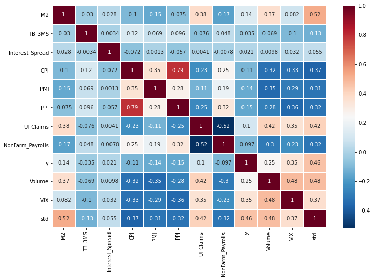

```python
plt.subplots(figsize=(12, 8))
sns.heatmap(sp500_marco_std.corr(), linewidths=1, cmap="RdBu_r", annot=True)
```

```python
sp500_marco_std = sp500_marco_std.drop(columns=["TB_3MS" , "PPI", "CPI", "Interest_Spread", "NonFarm_Payrolls"])
sp500_marco_std.dropna(axis = 0 , inplace = True)
sp500_marco_std
```

| Date | M2 | PMI | UI_Claims | y | Volume | VIX | std |
| --- | --- | --- | --- | --- | --- | --- | --- |
| 2000-06-30 | 0.012917 | -0.063752 | 0.056391 | 0.017482 | -0.099464 | -0.184427 | 0.033088 |
| 2000-07-31 | 0.004782 | -0.040219 | 0.024055 | 0.023710 | -0.096003 | -0.209700 | 0.025003 |
| 2000-08-31 | 0.013475 | -0.062030 | 0.114286 | 0.026698 | -0.075118 | -0.300414 | 0.017884 |
| 2000-09-30 | 0.017277 | -0.033074 | 0.039146 | 0.031532 | -0.023516 | 0.094866 | 0.017482 |
| 2000-10-31 | 0.016792 | -0.072381 | 0.010067 | 0.030915 | 0.105848 | 0.182214 | 0.023710 |
| ... | ... | ... | ... | ... | ... | ... | ... |
| 2020-05-31 | 0.156776 | -0.139721 | 7.741935 | 0.024512 | 0.678143 | -0.221766 | 0.078623 |
| 2020-06-30 | 0.135973 | 0.071283 | -0.794961 | 0.021939 | 0.116983 | -0.450452 | 0.039571 |
| 2020-07-31 | 0.076510 | 0.306024 | -0.692009 | 0.025532 | -0.092664 | -0.284481 | 0.028740 |
| 2020-08-31 | 0.029969 | 0.299304 | -0.534001 | 0.025989 | -0.201959 | -0.010323 | 0.024512 |
| 2020-09-30 | 0.026662 | 0.053232 | -0.397017 | 0.021578 | -0.241888 | -0.117981 | 0.021939 |

244 rows × 7 columns

### Model

```python
X_sp500_std = sp500_marco_std.drop(["y"], axis=1)
y_sp500_std = sp500_marco_std[["y"]]

# X_sp500_std_train, X_sp500_std_test, y_sp500_std_train, y_sp500_std_test=train_test_split(X_sp500_std, y_sp500_std
#                                                                           ,test_size=0.15, random_state=24)

X_sp500_std_train = X_sp500_std[:223]
X_sp500_std_test = X_sp500_std[223:]
y_sp500_std_train = y_sp500_std[:223]
y_sp500_std_test = y_sp500_std[223:]

scaler=StandardScaler()
X_sp500_train_std_scale=scaler.fit_transform(X_sp500_std_train)
X_sp500_test_scale=scaler.transform(X_sp500_std_test)
```

```python
print("X_sp500_train",X_sp500_std_train.shape)
print("X_sp500_test",X_sp500_std_test.shape)
print("y_sp500_train",y_sp500_std_train.shape)
print("y_sp500_test",y_sp500_std_test.shape)
```

```
X_sp500_train (223, 6)
X_sp500_test (21, 6)
y_sp500_train (223, 1)
y_sp500_test (21, 1)
```

```python
std_mae_compare=pd.DataFrame(columns=["Algorithm", "MAE", "Score"])
```

##### LinearRegression

```python
lr=LinearRegression()
lr.fit(X_sp500_train_std_scale, y_sp500_std_train)
lr_pred=lr.predict(X_sp500_train_std_scale)

#mae_compare["LinearRegression"]=mean_absolute_error(y_sp500_train, lr_pred)
std_mae_compare=std_mae_compare.append({"Algorithm":"LinearRegression",
             "MAE":mean_absolute_error(y_sp500_std_train, lr_pred),
                                "Score":lr.score(X_sp500_train_std_scale, y_sp500_std_train)}, ignore_index=True)
```

##### Stochastic Gradient Descent Regressor

```python
sgdr=SGDRegressor()
sgdr.fit(X_sp500_train_std_scale, y_sp500_std_train)
sgdr_pred=sgdr.predict(X_sp500_train_std_scale)

# mae_compare["SGDRegressor"]=mean_absolute_error(y_sp500_train, sgdr_pred)
std_mae_compare=std_mae_compare.append({"Algorithm":"SGDRegressor",
             "MAE":mean_absolute_error(y_sp500_std_train, sgdr_pred),
                                "Score":sgdr.score(X_sp500_train_std_scale, y_sp500_std_train)}, ignore_index=True)
```

##### Lasso

```python
lasso = Lasso()#(alpha=0.0005)
lasso.fit(X_sp500_train_std_scale, y_sp500_std_train)
lasso_pred = lasso.predict(X_sp500_train_std_scale)

# mae_compare["Lasso"]=mean_absolute_error(y_sp500_train, lasso_pred)
std_mae_compare=std_mae_compare.append({"Algorithm":"Lasso",
             "MAE":mean_absolute_error(y_sp500_std_train, lasso_pred),
                                "Score":lasso.score(X_sp500_train_std_scale, y_sp500_std_train)}, ignore_index=True)
```

##### Ridge

```python
ridge = Ridge()#(alpha=0.002)
ridge.fit(X_sp500_train_std_scale, y_sp500_std_train)
ridge_pred = ridge.predict(X_sp500_train_std_scale)

# mae_compare["Ridge"]=mean_absolute_error(y_sp500_train, ridge_pred)
std_mae_compare=std_mae_compare.append({"Algorithm":"Ridge",
             "MAE":mean_absolute_error(y_sp500_std_train, ridge_pred),
                                "Score":ridge.score(X_sp500_train_std_scale, y_sp500_std_train)}, ignore_index=True)
```

##### Linear SVM

```python
svm_reg=LinearSVR()
svm_reg.fit(X_sp500_train_std_scale, y_sp500_std_train)
svm_reg_pred=svm_reg.predict(X_sp500_train_std_scale)

# mae_compare["LinearSVM"]=mean_absolute_error(y_sp500_train, svm_reg_pred)
std_mae_compare=std_mae_compare.append({"Algorithm":"LinearSVM",
             "MAE":mean_absolute_error(y_sp500_std_train, svm_reg_pred),
                                "Score":svm_reg.score(X_sp500_train_std_scale, y_sp500_std_train)}, ignore_index=True)
```

##### Decision Tree Regressor

```python
tree_reg=DecisionTreeRegressor()#(max_depth=2)
tree_reg.fit(X_sp500_std_train, y_sp500_std_train)
tree_reg_pred=tree_reg.predict(X_sp500_std_train)

# mae_compare["DecisionTreeRegressor"]=mean_absolute_error(y_sp500_train, tree_reg_pred)
std_mae_compare=std_mae_compare.append({"Algorithm":"DecisionTreeRegressor",
             "MAE":mean_absolute_error(y_sp500_std_train, tree_reg_pred),
                                "Score":tree_reg.score(X_sp500_std_train,
                                                       y_sp500_std_train)}, ignore_index=True)
```

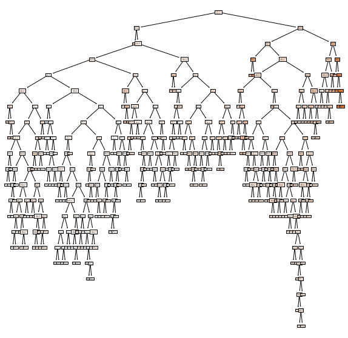

```python
fig = plt.figure(figsize=(10,10))
_ = tree.plot_tree(tree_reg, feature_names=X_sp500.columns, filled=True)
```

```python
pd.DataFrame({"features":X_sp500_std_train.columns, "features_importances":
              tree_reg.feature_importances_}).sort_values(by="features_importances", ascending=False)
```

|  | features | features_importances |
| --- | --- | --- |
| 5 | std | 0.368539 |
| 2 | UI_Claims | 0.201912 |
| 1 | PMI | 0.176273 |
| 3 | Volume | 0.163866 |
| 0 | M2 | 0.054852 |
| 4 | VIX | 0.034559 |

##### Random Forest Regressor

```python
rf = RandomForestRegressor()#(random_state=5)
rf.fit(X_sp500_std_train, y_sp500_std_train)
rf_pred = rf.predict(X_sp500_std_train)

# mae_compare["RandomForest"]=mean_absolute_error(y_sp500_train, rf_pred)
std_mae_compare=std_mae_compare.append({"Algorithm":"RandomForest",
             "MAE":mean_absolute_error(y_sp500_std_train, rf_pred),
                                "Score":rf.score(X_sp500_std_train, y_sp500_std_train)}, ignore_index=True)
```

##### Gradient Boosting Regressor

```python
gbr=GradientBoostingRegressor()#(max_depth=3, n_estimators=3, learning_rate=0.7)
gbr.fit(X_sp500_std_train, y_sp500_std_train)
gbr_pred=gbr.predict(X_sp500_std_train)

# mae_compare["GradientBoostingRegressor"]=mean_absolute_error(y_sp500_train, gbr_pred)
std_mae_compare=std_mae_compare.append({"Algorithm":"GradientBoostingRegressor",
             "MAE":mean_absolute_error(y_sp500_std_train, gbr_pred),
                                "Score":gbr.score(X_sp500_std_train, y_sp500_std_train)}, ignore_index=True)
```

```python
pd.DataFrame({"features":X_sp500_std_train.columns, "features_importances":
              gbr.feature_importances_}).sort_values(by="features_importances", ascending=False)
```

|  | features | features_importances |
| --- | --- | --- |
| 5 | std | 0.393367 |
| 2 | UI_Claims | 0.214347 |
| 3 | Volume | 0.171462 |
| 1 | PMI | 0.106301 |
| 0 | M2 | 0.097980 |
| 4 | VIX | 0.016544 |

##### XGBoost Regressor

```python
xgbr=XGBRegressor()
xgbr.fit(X_sp500_std_train, y_sp500_std_train)
xgbr_pred=xgbr.predict(X_sp500_std_train)

# mae_compare["XGBoostRegressor"]= mean_absolute_error(y_sp500_train, xgbr_pred)
std_mae_compare=std_mae_compare.append({"Algorithm":"XGBoostRegressor",
             "MAE":mean_absolute_error(y_sp500_std_train, xgbr_pred),
                                "Score":xgbr.score(X_sp500_std_train, y_sp500_std_train)}, ignore_index=True)
```

```python
std_mae_compare.set_index(["Algorithm"])
```

| Algorithm | MAE | Score |
| --- | --- | --- |
| LinearRegression | 0.006183 | 0.409216 |
| SGDRegressor | 0.006094 | 0.397518 |
| Lasso | 0.008459 | 0.000000 |
| Ridge | 0.006185 | 0.409207 |
| LinearSVM | 0.006291 | 0.282526 |
| DecisionTreeRegressor | 0.000000 | 1.000000 |
| RandomForest | 0.002247 | 0.926466 |
| GradientBoostingRegressor | 0.002323 | 0.941105 |
| XGBoostRegressor | 0.000603 | 0.995489 |

```python
from sklearn.model_selection import GridSearchCV

# Tuning XGBoost
param_grid = [{"n_estimators": [10, 200, 300],
               "learning_rate": [0.01, 0.05, 0.1],
              "max_depth": [3, 4, 5]}]

std_xgbr_tuning = XGBRegressor()
grid_search = GridSearchCV(std_xgbr_tuning, param_grid, cv=5,
                           scoring="neg_mean_squared_error")

grid_search.fit(X_sp500_std_train, y_sp500_std_train)

grid_search.best_params_
```

```
{'learning_rate': 0.05, 'max_depth': 3, 'n_estimators': 200}
```

```python
param_grid = [{"n_estimators": [200, 300, 400],
              "max_depth": [1, 2, 3]}]

std_rfg_tuning = RandomForestRegressor()
grid_search = GridSearchCV(std_rfg_tuning, param_grid, cv=5,
                           scoring="neg_mean_squared_error")

grid_search.fit(X_sp500_std_train, y_sp500_std_train)

grid_search.best_params_
```

```
{'max_depth': 2, 'n_estimators': 300}
```

```python
param_grid = [{"n_estimators": [300, 400, 500],
               "learning_rate": [0.001, 0.005, 0.01],
              "max_depth": [1, 2, 3]}]

std_gbr_tuning = GradientBoostingRegressor()
grid_search = GridSearchCV(std_gbr_tuning, param_grid, cv=5,
                           scoring="neg_mean_squared_error")

grid_search.fit(X_sp500_std_train, y_sp500_std_train)

grid_search.best_params_
```

```
{'learning_rate': 0.01, 'max_depth': 1, 'n_estimators': 500}
```

```python
param_grid = [{"max_features": [3, 4, 5],
              "max_depth": [2, 3, 4]}]

std_dtr_tuning = DecisionTreeRegressor()
grid_search = GridSearchCV(std_dtr_tuning, param_grid, cv=5,
                           scoring="neg_mean_squared_error")

grid_search.fit(X_sp500_std_train, y_sp500_std_train)

grid_search.best_params_
```

```
{'max_depth': 4, 'max_features': 4}
```

```python
################
std_dtr_final_model = DecisionTreeRegressor(max_features=4, max_depth=4)

std_dtr_final_model.fit(X_sp500_std_train, y_sp500_std_train)
std_dtr_pred_train = std_dtr_final_model.predict(X_sp500_std_train)
std_dtr_pred_test = std_dtr_final_model.predict(X_sp500_std_test)
```

```python
std_xgbr_final_model = XGBRegressor(n_estimators=200, learning_rate=0.05, max_depth=3)

std_xgbr_final_model.fit(X_sp500_std_train, y_sp500_std_train)
std_xgbr_pred_train = std_xgbr_final_model.predict(X_sp500_std_train)
std_xgbr_pred_test = std_xgbr_final_model.predict(X_sp500_std_test)
```

```python
std_rfg_final_model = RandomForestRegressor(n_estimators=300, max_depth=2)

std_rfg_final_model.fit(X_sp500_std_train, y_sp500_std_train)
std_rfg_pred_train = std_rfg_final_model.predict(X_sp500_std_train)
std_rfg_pred_test = std_rfg_final_model.predict(X_sp500_std_test)
```

```python
std_gbr_final_model = GradientBoostingRegressor(n_estimators=500, learning_rate=0.01, max_depth=1)

std_gbr_final_model.fit(X_sp500_std_train, y_sp500_std_train)
std_gbr_pred_train = std_gbr_final_model.predict(X_sp500_std_train)
std_gbr_pred_test = std_gbr_final_model.predict(X_sp500_std_test)
```

```python
predict_train = pd.concat([pd.DataFrame(std_rfg_pred_train) , pd.DataFrame(std_xgbr_pred_train) , pd.DataFrame(std_gbr_pred_train)] , axis = 1)
predict_train.columns = ['rfg' , 'xgbr' , 'gbr']
predict_train.index = y_sp500_std_train.index
predict_train
```

| Date | rfg | xgbr | gbr |
| --- | --- | --- | --- |
| 2000-06-30 | 0.024910 | 0.020132 | 0.022444 |
| 2000-07-31 | 0.024738 | 0.022900 | 0.024517 |
| 2000-08-31 | 0.019016 | 0.021879 | 0.021154 |
| 2000-09-30 | 0.018344 | 0.026585 | 0.018934 |
| 2000-10-31 | 0.024738 | 0.024390 | 0.022444 |
| ... | ... | ... | ... |
| 2018-08-31 | 0.016217 | 0.021292 | 0.017884 |
| 2018-09-30 | 0.016272 | 0.023186 | 0.017884 |
| 2018-10-31 | 0.022458 | 0.027546 | 0.022972 |
| 2018-11-30 | 0.024917 | 0.025783 | 0.026737 |
| 2018-12-31 | 0.025660 | 0.019651 | 0.028109 |

223 rows × 3 columns

```python
predict_test = pd.concat([pd.DataFrame(std_rfg_pred_test) , pd.DataFrame(std_xgbr_pred_test) , pd.DataFrame(std_gbr_pred_test)] , axis = 1)
predict_test.columns = ['rfg' , 'xgbr' , 'gbr']
predict_test.index = y_sp500_std_test.index
predict_test
```

| Date | rfg | xgbr | gbr |
| --- | --- | --- | --- |
| 2019-01-31 | 0.024991 | 0.024466 | 0.024663 |
| 2019-02-28 | 0.024978 | 0.019335 | 0.022444 |
| 2019-03-31 | 0.018485 | 0.014321 | 0.018934 |
| 2019-04-30 | 0.016216 | 0.014625 | 0.017884 |
| 2019-05-31 | 0.015702 | 0.012006 | 0.015811 |
| 2019-06-30 | 0.015850 | 0.016416 | 0.015811 |
| 2019-07-31 | 0.015801 | 0.016038 | 0.015811 |
| 2019-08-31 | 0.021863 | 0.021256 | 0.020899 |
| 2019-09-30 | 0.021848 | 0.016892 | 0.020899 |
| 2019-10-31 | 0.021838 | 0.021948 | 0.020899 |
| 2019-11-30 | 0.015797 | 0.016143 | 0.015811 |
| 2019-12-31 | 0.015768 | 0.015817 | 0.015811 |
| 2020-01-31 | 0.015774 | 0.022461 | 0.015811 |
| 2020-02-29 | 0.023384 | 0.032454 | 0.020899 |
| 2020-03-31 | 0.061501 | 0.064820 | 0.057323 |
| 2020-04-30 | 0.061934 | 0.064678 | 0.057323 |
| 2020-05-31 | 0.060361 | 0.065967 | 0.057323 |
| 2020-06-30 | 0.027748 | 0.039363 | 0.029669 |
| 2020-07-31 | 0.025460 | 0.041854 | 0.025216 |
| 2020-08-31 | 0.024761 | 0.028780 | 0.021945 |
| 2020-09-30 | 0.024689 | 0.035379 | 0.022444 |

```python
predict = pd.concat([predict_train , predict_test] , axis = 0)
predict.to_csv('統計學習期末/std_predict_3model.csv')
```